# togga FPL statistics

Shaun Nielsen

24 August 2017

# playtogga

Functions and data for scraping/downloading playtogga FPL data.

# The process

With my limited expertise, I have put together some R functions for scraping the player tables from playtogga. The main scrape function uses RSelenium to run your browser, login, and then use a user-specified file (an updated file of each and every player is provided) that navigates to the player tables wanted and the HTMLs are saved. Another function extracts uses the XML package to extract tables from the HTMLs, cleans them and puts them into a list in R.

## Load all the functions and data

A number of functions and data is provided to do all the steps.

```r
setwd("C:/Users/Shaunus/Desktop/Togga/playtogga/Functions/")

for (f in list.files(pattern="*.R")) {
  source(f)
}

setwd("C:/Users/Shaunus/Desktop/Togga/playtogga/Data/")
load("eventScores.RData")
load("playerNamesURLs_Aug2017.RData")
```

## Downlading HTMLs

The playerURLTeamPosition has player names, playtogga URL, team, position and games played information. There are >550 players, and having to download all their HTMLs will take some time. At week 3 of 2017, I was selected only those who have played.

```r
head(playerURLTeamPosition)
```

```
           Name                URL Team POS gamesPlayed
1 H. Mkhitaryan epl/players/p57249  MUN MID           3
2      P. Pogba epl/players/p74208  MUN MID           3
3     R. Lukaku epl/players/p66749  MUN FOR           3
4      J. Lössl epl/players/p57513  HUD GOA           3
5      D. Blind epl/players/p58877  MUN DEF           3
6  C. Schindler epl/players/p85368  HUD DEF           3
```

```r
playerURLTeamPosition = playerURLTeamPosition[ playerURLTeamPosition$gamesPlayed > 0,]
```

Run the function `downloadPlayerHTMLs`, which will save the HTMLs in the current directory.

```r
downloadPlayerHTMLs(login = "user", password = "password", playerNameURL = playerURLTeamPosition)
```

## Cleaning player tables

```r
playerHTMLs = list.files(pattern = ".html")
```

The data table of each player is in a list.

```r
allPlayerTable.list[[1]][1:5,]
```

```
  GW         OPP  PTS G A CC SCR SOT STO AER CLR CS INT PS SV TW DIS GC OG YC RC
1  1 @MUN, L 4-0 -1.5 0 0  0   0   0   0   0   0  0   0  0  0  0   3  4  0  0  0
2  2 @SOU, L 3-2  4.0 0 0  0   0   0   0   3   0  0   1  0  0  2   1  2  0  0  0
3  3 @NEW, L 3-0  4.0 0 0  0   0   0   0   2   0  0   0  0  0  3   0  1  0  0  0
4  4        HUD,   NA 0 0  0   0   0   0   0   0  0   0  0  0  0   0  0  0  0  0
5  5       @WBA,   NA 0 0  0   0   0   0   0   0  0   0  0  0  0   0  0  0  0  0
```

For downstream use, we add the player name, team and position to this data.

```r
allPlayerTable.list <- addPlayerInfoToPlayerTable(allPlayerTable.list, playerURLTeamPosition)
allPlayerTable.list$`A. Ayew`[1:5,]
```

```
     Name Team POS GW         OPP  PTS G A CC SCR SOT STO AER CLR CS INT PS SV TW DIS GC OG YC RC
1 A. Ayew  WHU FOR  1 @MUN, L 4-0 -1.5 0 0  0   0   0   0   0   0  0   0  0  0  0   3  4  0  0  0
2 A. Ayew  WHU FOR  2 @SOU, L 3-2  4.0 0 0  0   0   0   0   3   0  0   1  0  0  2   1  2  0  0  0
3 A. Ayew  WHU FOR  3 @NEW, L 3-0  4.0 0 0  0   0   0   0   2   0  0   0  0  0  3   0  1  0  0  0
4 A. Ayew  WHU FOR  4        HUD,   NA 0 0  0   0   0   0   0   0  0   0  0  0  0   0  0  0  0  0
5 A. Ayew  WHU FOR  5       @WBA,   NA 0 0  0   0   0   0   0   0  0   0  0  0  0   0  0  0  0  0
```

Thus, for example, obtain the first 3 weeks of data.

```r
gameWeeksWanted = 1:3
allPlayerTableWks.list = lapply(allPlayerTable.list,  function(x) x[gameWeeksWanted,])

# Show only the first 5 [1:5]
allPlayerTableWks.list[1:5]
```

```
$`A. Ayew`
     Name Team POS GW         OPP  PTS G A CC SCR SOT STO AER CLR CS INT PS SV TW DIS GC OG YC RC
1 A. Ayew  WHU FOR  1 @MUN, L 4-0 -1.5 0 0  0   0   0   0   0   0  0   0  0  0  0   3  4  0  0  0
2 A. Ayew  WHU FOR  2 @SOU, L 3-2  4.0 0 0  0   0   0   0   3   0  0   1  0  0  2   1  2  0  0  0
3 A. Ayew  WHU FOR  3 @NEW, L 3-0  4.0 0 0  0   0   0   0   2   0  0   0  0  0  3   0  1  0  0  0

$`A. Barnes`
       Name Team POS GW         OPP  PTS G A CC SCR SOT STO AER CLR CS INT PS SV TW DIS GC OG YC RC
1 A. Barnes  BRN FOR  1 @CHE, W 2-3  0.0 0 0  0   0   0   0   0   0  0   0  0  0  0   0  0  0  0  0
2 A. Barnes  BRN FOR  2  WBA, L 0-1 -1.0 0 0  0   1   0   1   0   0  0   0  0  0  0   0  0  0  1  0
3 A. Barnes  BRN FOR  3 @TOT, D 1-1  0.5 0 0  0   0   0   0   2   0  0   0  0  0  0   1  0  0  0  0

$`A. Begovic`
        Name Team POS GW         OPP  PTS G A CC SCR SOT STO AER CLR CS INT PS SV TW DIS GC OG YC RC
1 A. Begovic  BOU GOA  1 @WBA, L 1-0 9.25 0 0  0   0   0   0   1   1  0   0  0  5  0   0  1  0  0  0
2 A. Begovic  BOU GOA  2  WAT, L 0-2 6.25 0 0  0   0   0   0   0   1  0   0  0  5  0   0  2  0  0  0
3 A. Begovic  BOU GOA  3  MCI, L 1-2 8.75 0 0  0   0   0   0   0   3  0   0  0  6  0   0  2  0  0  0

$`A. Carrillo`
         Name Team POS GW        OPP PTS G A CC SCR SOT STO AER CLR CS INT PS SV TW DIS GC OG YC RC
1 A. Carrillo  WAT MID  1       LIV,  NA 0 0  0   0   0   0   0   0  0   0  0  0  0   0  0  0  0  0
2 A. Carrillo  WAT MID  2      @BOU,  NA 0 0  0   0   0   0   0   0  0   0  0  0  0   0  0  0  0  0
3 A. Carrillo  WAT MID  3 BHA, D 0-0   2 0 0  0   0   0   1   1   0  0   0  0  0  1   1  0  0  0  0

$`A. Christensen`
            Name Team POS GW         OPP  PTS G A CC SCR SOT STO AER CLR CS INT PS SV TW DIS GC OG YC RC
1 A. Christensen  CHE DEF  1  BRN, L 2-3 0.25 0 0  1   0   0   1   2   1  0   1  0  0  0   0  3  0  0  0
2 A. Christensen  CHE DEF  2 @TOT, W 1-2 3.00 0 0  0   0   0   0   2   8  0   1  0  0  0   0  1  0  0  0
3 A. Christensen  CHE DEF  3  EVE, W 2-0 1.00 0 0  0   0   0   0   1   0  0   0  0  0  0   0  0  0  0  0
```

## Fitting GLMs to each variable

Here, I assume the count of each variable/statistic (goal, assists, etc) is Poisson distributed, and will fit a GLM to each one for each player using the previous weeks data. I use the fits to look at the probability of the counts for each variable. This is done using `fitAllStatPoissonGLMs`. The result is a list of GLMs fit for each player for each statistic.

```r
playerGlms.list = fitAllStatPoissonGLMs(allPlayerTableWks.list)
attributes(playerGlms.list$`A. Ayew`)
```

```
$names
 [1] "G"   "A"   "CC"  "SCR" "SOT" "STO" "AER" "CLR" "CS"  "INT" "PS"  "SV"  "TW"  "DIS" "GC"  "OG"  "YC"  "RC"
```

```r
playerGlms.list$`A. Ayew`$G
```

```
$glmOut

Call:  glm(formula = x ~ 1, family = poisson)

Coefficients:
(Intercept)
      -23.3

Degrees of Freedom: 2 Total (i.e. Null);  2 Residual
Null Deviance:      0
Residual Deviance: 4.55e-10     AIC: 2

$lamdaFit
(Intercept)
  -23.30259

$outPcnt
           0            1            2            3
1.000000e+02 7.582560e-09 2.874761e-19 7.266017e-30
```

We can plot the distributions of the statistics for one player using `plotOnePlayerDistributions`, or all players using `plotAllPlayerDistributions`.

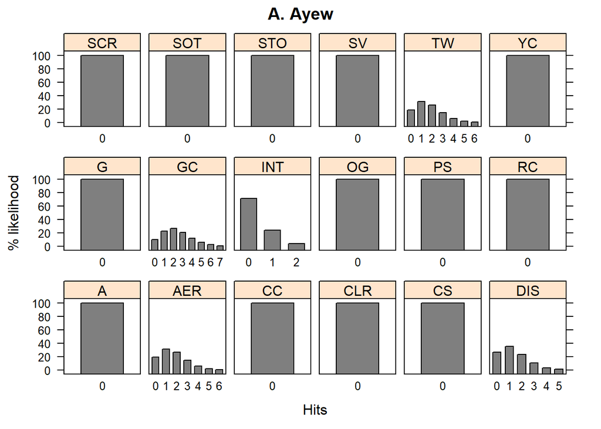

```r
plotOnePlayerDistributions(playerGlms.list$`A. Ayew`, main = "A. Ayew")
```

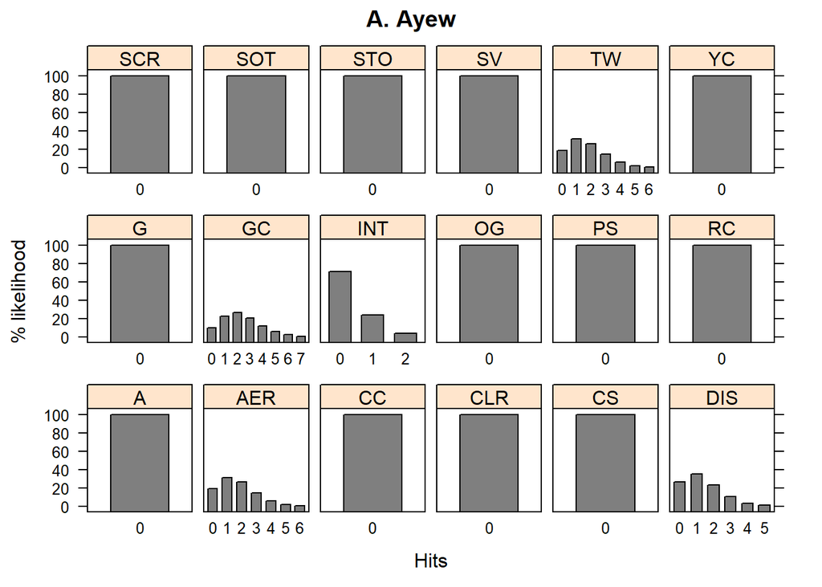

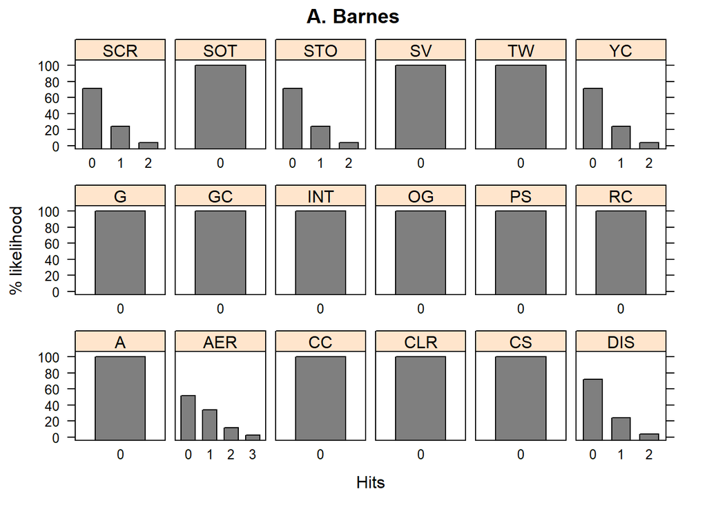

```r
plotAllPlayerDistributions(playerGlms.list[1:2])
```

## Predicting scores

The most likely score given the distribution in the figures above uses `mostLikelyStatistics`.

```r
mostLikelyStatistics(playerGlms.list)["H. Mkhitaryan",]
```

```
  G   A  CC SCR SOT STO AER CLR  CS INT  PS  SV  TW DIS  GC  OG  YC  RC
  0   1   4   0   0   2   0   0   1   0   0   0   1   2   0   0   0   0
```

For which we can work out the togga points.

```r
playerMLStats = mostLikelyStatistics(playerGlms.list)
pNnames = row.names(playerMLStats)
playerMLStats = data.frame(POS = playerURLTeamPosition$POS[sapply(pNnames, function(x) which(x == playerURLTeamPosition$Name))],playerMLStats)

predictedPoints = calculateBytoggaScores(list(playerMLStats), eventScores)
predictedPoints[1:5,]
```

```
       A. Ayew      A. Barnes     A. Begovic    A. Carrillo A. Christensen
          1.00           0.00          -1.75           0.00           0.50
```

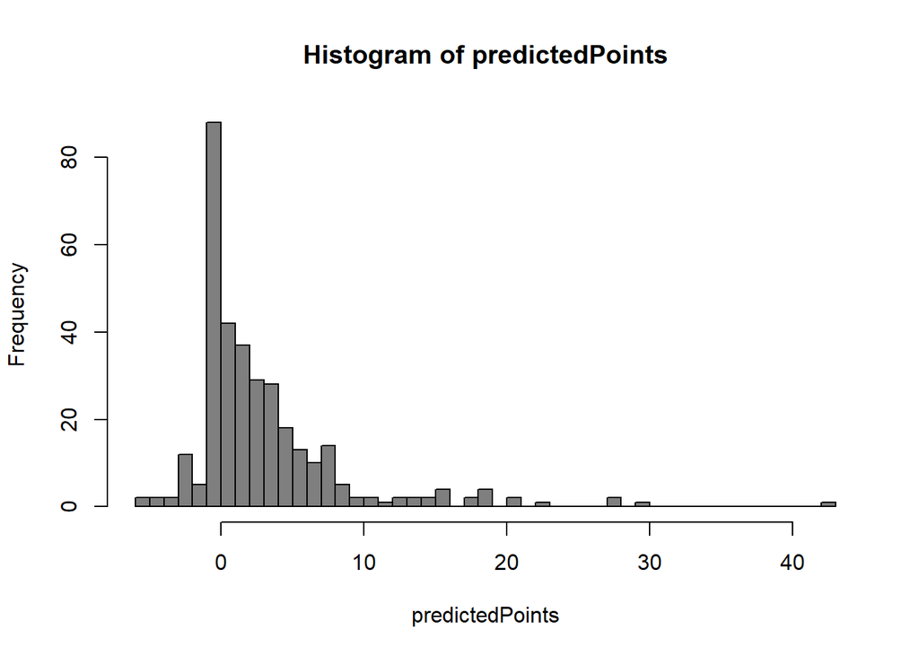

```r
hist(predictedPoints, breaks = 40, col = "grey50")
```

```r
qqScoresList = getPlayerQuantiles(playerGlms.list, allPlayerTable.list, quantiles = c(10,25,50,75,90))
qqScoresList$Q50[1:5,]
```

```
                         Name Team POS G A CC SCR SOT STO AER CLR CS INT PS SV TW DIS GC OG YC RC
A. Ayew               A. Ayew  WHU FOR 0 0  0   0   0   0   1   0  0   0  0  0  1   1  2  0  0  0
A. Barnes           A. Barnes  BRN FOR 0 0  0   0   0   0   0   0  0   0  0  0  0   0  0  0  0  0
A. Begovic         A. Begovic  BOU GOA 0 0  0   0   0   0   0   1  0   0  0  5  0   0  1  0  0  0
A. Carrillo       A. Carrillo  WAT MID 0 0  0   0   0   0   0   0  0   0  0  0  0   0  0  0  0  0
A. Christensen A. Christensen  CHE DEF 0 0  0   0   0   0   1   3  0   0  0  0  0   0  1  0  0  0
```

We can then use the event scoring table from playtogga to work out the points scored given the statistics using `calculateBytoggaScores`.

```r
predictedPointsQQ = calculateBytoggaScores(qqScoresList, eventScores)
predictedPointsQQ[1:10,]
```

```
               Q10   Q25   Q50   Q75   Q90
A. Ayew          0  1.50  1.00  3.00  4.00
A. Barnes        0  0.00  0.00 -1.00 -0.50
A. Begovic       0 -1.75 -1.75 -2.50 -4.25
A. Carrillo      0  0.00  0.00  2.50  2.50
A. Christensen   0  0.50  0.50  5.00  6.50
A. Cresswell     0  0.00  3.00  9.50 11.50
A. Doucouré      1  1.25  9.50 37.25 39.00
A. Gray          0 -0.50 -0.50  6.50  6.50
A. Hegazi        1  1.50  4.00 20.00 21.50
A. Herrera       0  0.00  0.00  0.00  0.00
```

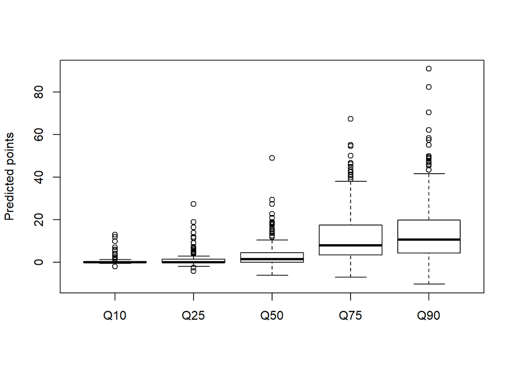

```r
boxplot(predictedPointsQQ, ylab = "Predicted points", font.lab = 2)
```

If we are more inclined, we can plot the predictions across the quantiles.

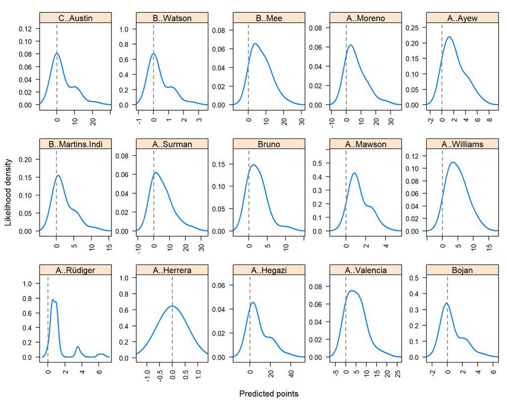

```r
qqScoresList = getPlayerQuantiles(playerGlms.list, allPlayerTableWks.list, quantiles = seq(1,99, length = 50))
playerScores = data.frame(t(calculateBytoggaScores(qqScoresList, eventScores)))
set.seed(1010)
samplePlayers = sample(1:nrow(playerScores), size = 15)
playerScores = playerScores[, samplePlayers]
playerScores.stack = stack(playerScores)
playerScores.stack$QQ = row.names(playerScores)

densityplot(~values | ind, data = playerScores.stack,
            layout = c(5,3), between = list(y = 0.5),
            xlab = "Predicted points", ylab = "Likelihood density",
            scales = list(alternating = F,
                            y = list(relation = "free", rot = 0),
                            x = list(relation = "free", rot = 90)), #limits = c(-10,30))),
            panel = function(x){
              panel.densityplot(x, plot.points = F, adjust = 5,darg = list(adjust = 1.5), lwd = 2)
              panel.abline(v = 0, col = "grey50", lwd = 1.5, lty = 2)
              })
```